# projekt_R_czesc_1_regresja

Będziemy pracować na danych z biblioteki MASS dotyczących kotów. Dane składają się z 144 próbek, każda próbka zawiera informacje o płci kota (zmienna Sex - ‘F’ albo ‘M’), jego masie ciała w kilogramach (zmienna Bwt) i masie jego serca w gramach (zmienna Hwt). Dane dotyczą dorosłych kotów o masie ciała powyżej 2 kg.

```r
library(MASS)
data(cats)

head(cats)
```

```
##   Sex Bwt Hwt
## 1   F 2.0 7.0
## 2   F 2.0 7.4
## 3   F 2.0 9.5
## 4   F 2.1 7.2
## 5   F 2.1 7.3
## 6   F 2.1 7.6
```

Celem pierwszej części naszej analizy jest sprawdzenie za pomocą regresji liniowej prostej, jak dobrze można przewidzeć masę serca kota na podstawie wiedzy o jego masie ciała. Zauważmy, że taka wiedza może być przydatna w weterynarii, gdyż kota jest łatwo zważyć, a jego serce raczej trudno.

Sprawdzimy najpierw, czy dane o masach kotów oraz masach ich serc mają rozkłady zbliżone do normalnego.

Histogram mas kotów:

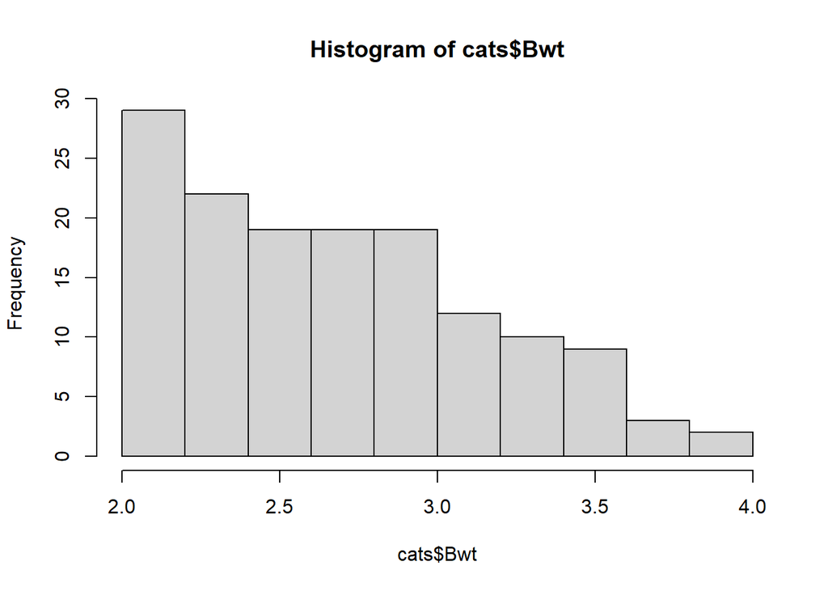

```r
hist(cats$Bwt)
```

Sprawdzenie czy dane mogą pochodzić z rozkładu normalnego.

```r
shapiro.test(cats$Bwt)
```

```
##
##  Shapiro-Wilk normality test
##
## data:  cats$Bwt
## W = 0.95188, p-value = 6.731e-05
```

Dane raczej nie pochodzą z rokładu normalnego.

Histogram mas serc kotów:

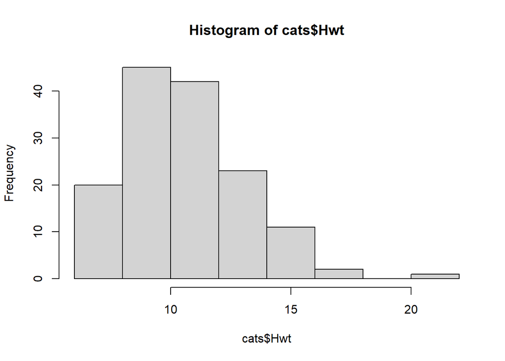

```r
hist(cats$Hwt)
```

```r
shapiro.test(cats$Hwt)
```

```
##
##  Shapiro-Wilk normality test
##
## data:  cats$Hwt
## W = 0.96039, p-value = 0.0003654
```

I w tym przypadku nie mamy normalności danych.

W obu przypadkach widzimy, że rozkłady nie przypominają rozkładu normalnego, dlatego zastosujemy do obu zestawów danych funkcję logarytm.

```r
log_Bwt = log(cats$Bwt)
log_Hwt = log(cats$Hwt)
```

Sprawdźmy, czy teraz rozkłady cech bardziej przypominają rozkład normalny.

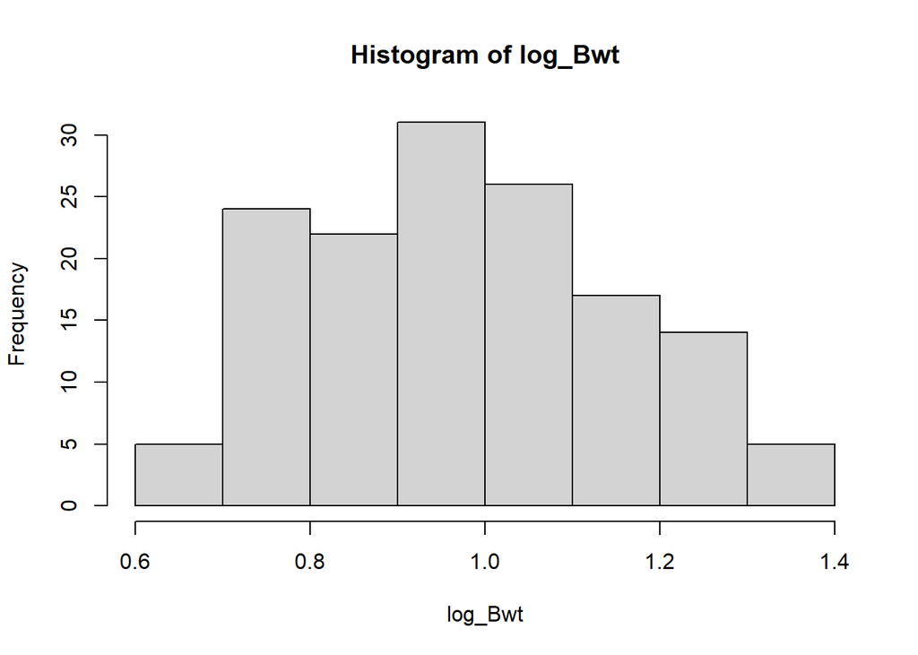

```r
hist(log_Bwt)
```

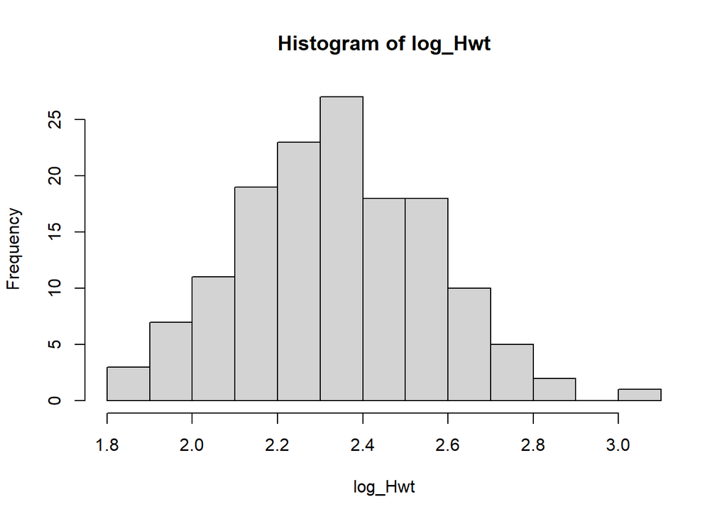

```r
hist(log_Hwt)
```

Jest zauważalnie lepiej. Na podstawie histogramu logarytmu masy serca widzmy obecność elementu odstającego po prawej stronie, jednak na razie go zignorujmy, wyeliminujemy go budując drugi model. Przechodzimy zatem do dalszej analizy.

Zbudujmy pierwszy model regresji liniowej prostej dla naszych danych, za zmienną objaśnianą przyjmując masę serca kota.

```r
first_model <- lm(log_Hwt ~ log_Bwt)
summary(first_model)
```

```
##
## Call:
## lm(formula = log_Hwt ~ log_Bwt)
##
## Residuals:
##      Min       1Q   Median       3Q      Max
## -0.38614 -0.09404  0.00065  0.09354  0.30337
##
## Coefficients:
##             Estimate Std. Error t value Pr(>|t|)
## (Intercept)  1.34246    0.06446   20.83   <2e-16 ***
## log_Bwt      1.01001    0.06434   15.70   <2e-16 ***
## ---
## Signif. codes:  0 '***' 0.001 '**' 0.01 '*' 0.05 '.' 0.1 ' ' 1
##
## Residual standard error: 0.1348 on 142 degrees of freedom
## Multiple R-squared:  0.6344, Adjusted R-squared:  0.6319
## F-statistic: 246.5 on 1 and 142 DF,  p-value: < 2.2e-16
```

Oba współczynniki obecne w modelu są bardzo istotne, a udało nam się wyjaśnić 63% wariancji w danych. Jest to niezły wynik, chociaż mogłoby być lepiej.

Zobaczmy jak wygląda nasza chmura punktów naniesiona na płaszczyznę oraz jak wygląda krzywa regresji.

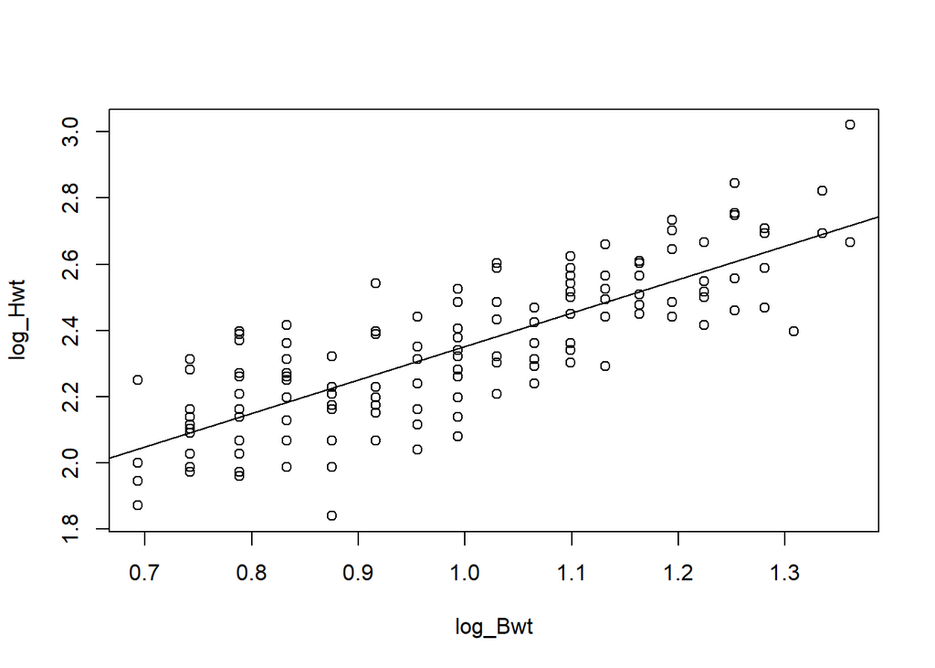

```r
plot(log_Bwt,log_Hwt)
abline(first_model)
```

Widzimy ewidentny trend liniowy oraz nie tak znowu duży rozrzut wokół prostej regresji.

Popatrzmy teraz na wykres rozrzutu reszt w naszym modelu.

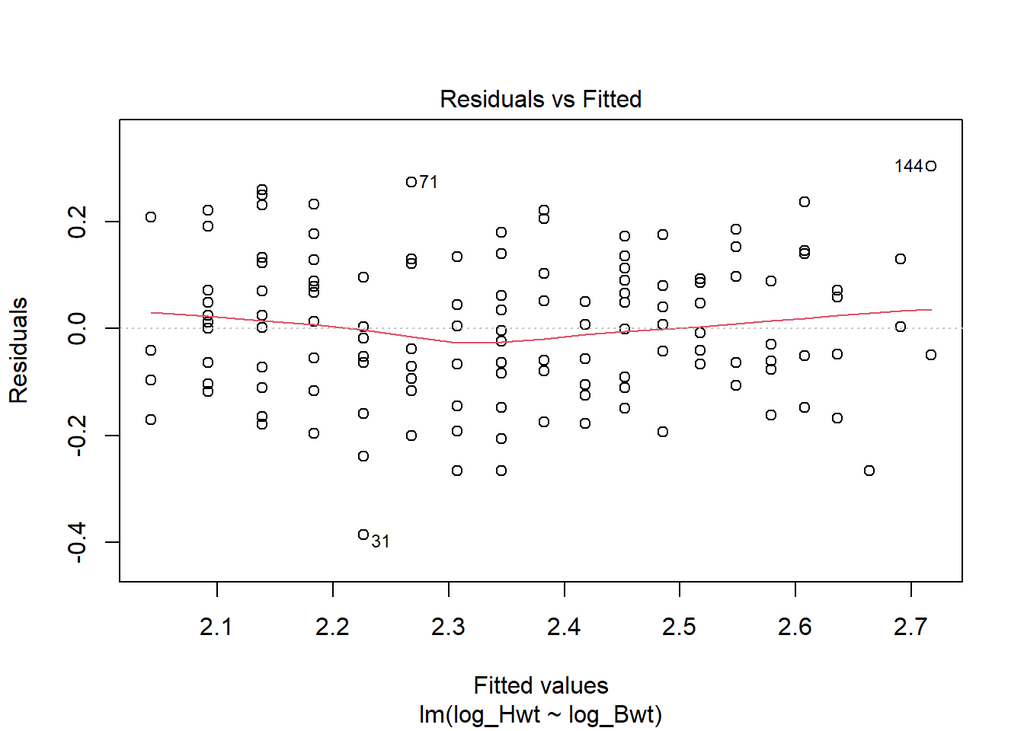

```r
plot(first_model, which=1)
```

Widzimy, że wariancja reszt jest w miarę stała, zatem wstępnie wnioskujemy o homoskedastyczności reszt. Podobnie, na podstawie wykresu można wstępnie powiedzieć, że średnia reszt jest równa zero. Przeprowadźmy teraz odpowiednie testy aby się o tym przekonać.

Najpierw zajmijmy się normalnością reszt. Przeprowadźmy test Shapiro-Wilka.

```r
shapiro.test(first_model$residuals)
```

```
##
##  Shapiro-Wilk normality test
##
## data:  first_model$residuals
## W = 0.99021, p-value = 0.4144
```

Duża p-wartość sugeruje, że dane mają w przybliżeniu rozkład normalny. Aby dopełnić obowiązku sprawdzania normalności reszt zerknijmy na QQ-plot.

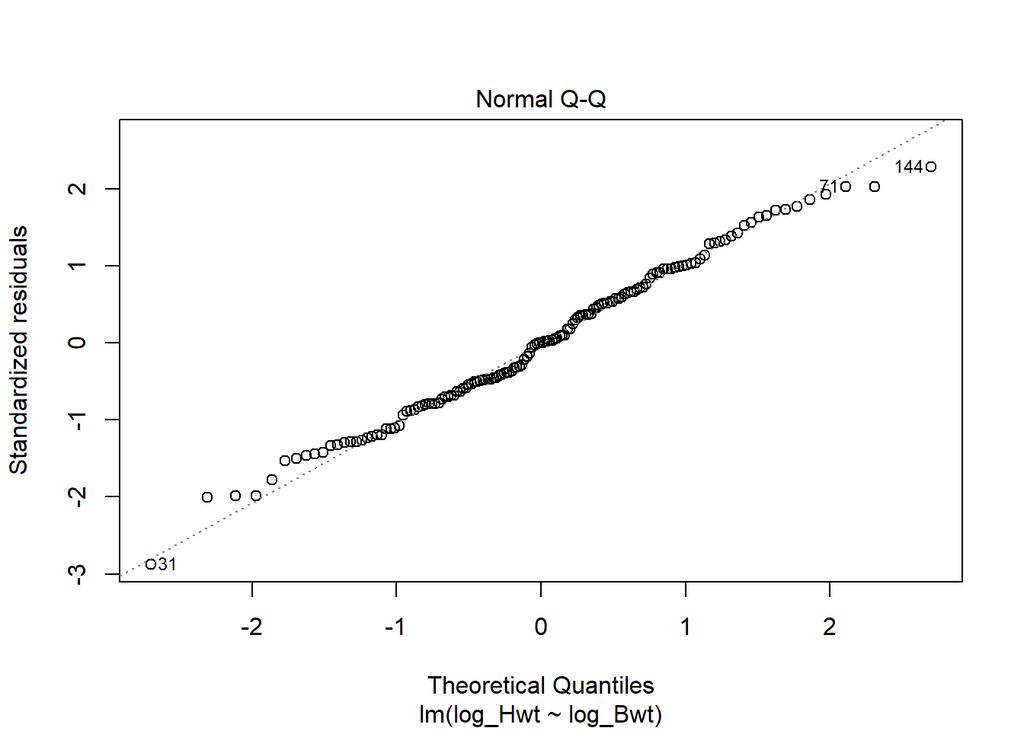

```r
plot(first_model, which=2)
```

Otrzymany wykres potwierdza wynik testu Shapiro-Wilka i świadczy o normalności reszt.

Następnie sprawdzamy, czy średnia reszt jest równa zero z pomocą testu t-Studenta.

```r
t.test(first_model$residuals)
```

```
##
##  One Sample t-test
##
## data:  first_model$residuals
## t = 3.9272e-17, df = 143, p-value = 1
## alternative hypothesis: true mean is not equal to 0
## 95 percent confidence interval:
##  -0.0221318  0.0221318
## sample estimates:
##    mean of x
## 4.397042e-19
```

P-wartość jest bardzo duża, zatem otrzymujemy potwierdzenie tego, co widzeliśmy wcześniej na wykresie rozrzutu reszt - średnia reszt jest w przybliżeniu równa zero.

Kolejno sprawdźmy niezależność reszt jestem Durbina-Watsona.

```r
lmtest::dwtest(first_model)
```

```
##
##  Durbin-Watson test
##
## data:  first_model
## DW = 1.5989, p-value = 0.006092
## alternative hypothesis: true autocorrelation is greater than 0
```

Otrzymana p-wartość świadczy o obecności autokorelacji w danych, czyli założenie o niezależności reszt jest niestety złamane.

Sprawdźmy jeszcze za pomocą testu Breusch-Pagan, czy reszty na pewno są homoskedastyczne.

```r
lmtest::bptest(first_model)
```

```
##
##  studentized Breusch-Pagan test
##
## data:  first_model
## BP = 0.41145, df = 1, p-value = 0.5212
```

Duża p-wartość przemawia za tezą, że są.

Sprawdżmy teraz, czy eliminacja elementu odstającego w zmiennej log_Hwt pomoże nam ulepszyć model. Ponieważ element odstający znajduje się w wierszu nr 144 wyrzucamy go z ramki danych i przypisujemy zlogatytmowane wartości do zmiennych.

```r
log_Hwt_2 <- log(cats[-144,]$Hwt)
log_Bwt_2 <- log(cats[-144,]$Bwt)
```

Budujemy drugi model bez elementu odstającego.

```r
second_model <- lm(log_Hwt_2 ~ log_Bwt_2)
summary(second_model)
```

```
##
## Call:
## lm(formula = log_Hwt_2 ~ log_Bwt_2)
##
## Residuals:
##      Min       1Q   Median       3Q      Max
## -0.38694 -0.09554 -0.00071  0.09611  0.27398
##
## Coefficients:
##             Estimate Std. Error t value Pr(>|t|)
## (Intercept)  1.36681    0.06433   21.25   <2e-16 ***
## log_Bwt_2    0.98310    0.06440   15.27   <2e-16 ***
## ---
## Signif. codes:  0 '***' 0.001 '**' 0.01 '*' 0.05 '.' 0.1 ' ' 1
##
## Residual standard error: 0.1328 on 141 degrees of freedom
## Multiple R-squared:  0.623,  Adjusted R-squared:  0.6204
## F-statistic:   233 on 1 and 141 DF,  p-value: < 2.2e-16
```

Nastąpiła ciekawa rzecz - drugi model jest minimalnie gorszy od pierwszego. Zostawiamy go zatem i przechodzimy do budowania modelu regresji wielokrakiej przez umieszczenie w modelu informacji o płci badanego kota. W dalszej części będziemy pracować z, najwyraźniej potrzebnym, elementem odstającym.

```r
third_model <- lm(log_Hwt ~ log_Bwt + cats$Sex)
summary(third_model)
```

```
##
## Call:
## lm(formula = log_Hwt ~ log_Bwt + cats$Sex)
##
## Residuals:
##      Min       1Q   Median       3Q      Max
## -0.39186 -0.09970 -0.00116  0.09194  0.30101
##
## Coefficients:
##             Estimate Std. Error t value Pr(>|t|)
## (Intercept)  1.33417    0.06804  19.609   <2e-16 ***
## log_Bwt      1.02601    0.07641  13.428   <2e-16 ***
## cats$SexM   -0.01113    0.02846  -0.391    0.696
## ---
## Signif. codes:  0 '***' 0.001 '**' 0.01 '*' 0.05 '.' 0.1 ' ' 1
##
## Residual standard error: 0.1352 on 141 degrees of freedom
## Multiple R-squared:  0.6348, Adjusted R-squared:  0.6297
## F-statistic: 122.6 on 2 and 141 DF,  p-value: < 2.2e-16
```

Okazuje się, że płeć kota nie jest informacją istotną w naszym modelu, co jest rzeczą dosyć ciekawą i niespodziewaną, gdyż można by przypuszczać, że samce będą posiadać masywniejsze serca od samic i pomoże to w predykcji masy serca kota, ale nasz model na to nie wskazuje. Jest to z pewnością rzecz warta dalszego badania i konsultacji ze specjalistami z dziedziny anatomii kota.

Aby dowiedzieć się czegoś więcej na temat różnic pomiędzy samcami i samicami dorosłych kotów zobaczmy jak masa ciała oraz masa serca wyglądają na wykresie punktowym oraz na wykresach pudełkowych w przypadku obu płci.

```r
library(tidyverse)
```

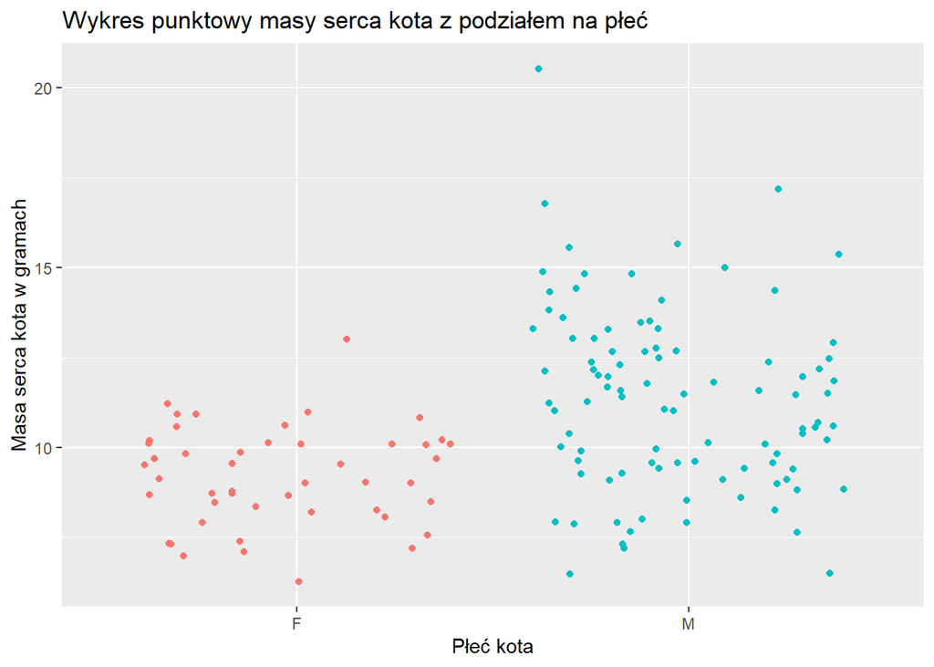

```r
ggplot(cats, aes(x=Sex, y=Hwt)) + geom_point(aes(color=Sex), position='jitter') + labs(title = 'Wykres punktowy masy serca kota z podziałem na płeć', x='Płeć kota', y='Masa serca kota w gramach') + theme(legend.position = 'none')
```

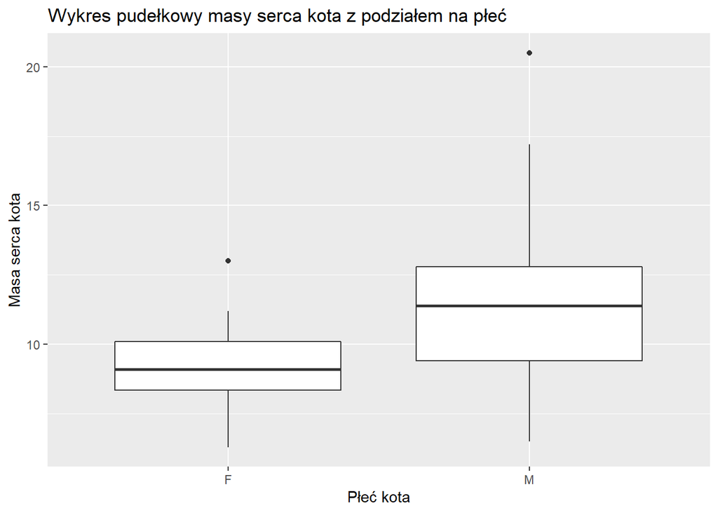

```r
ggplot(cats, aes(x=Sex, y=Hwt)) + geom_boxplot() + labs(title = "Wykres pudełkowy masy serca kota z podziałem na płeć", x='Płeć kota', y='Masa serca kota')
```

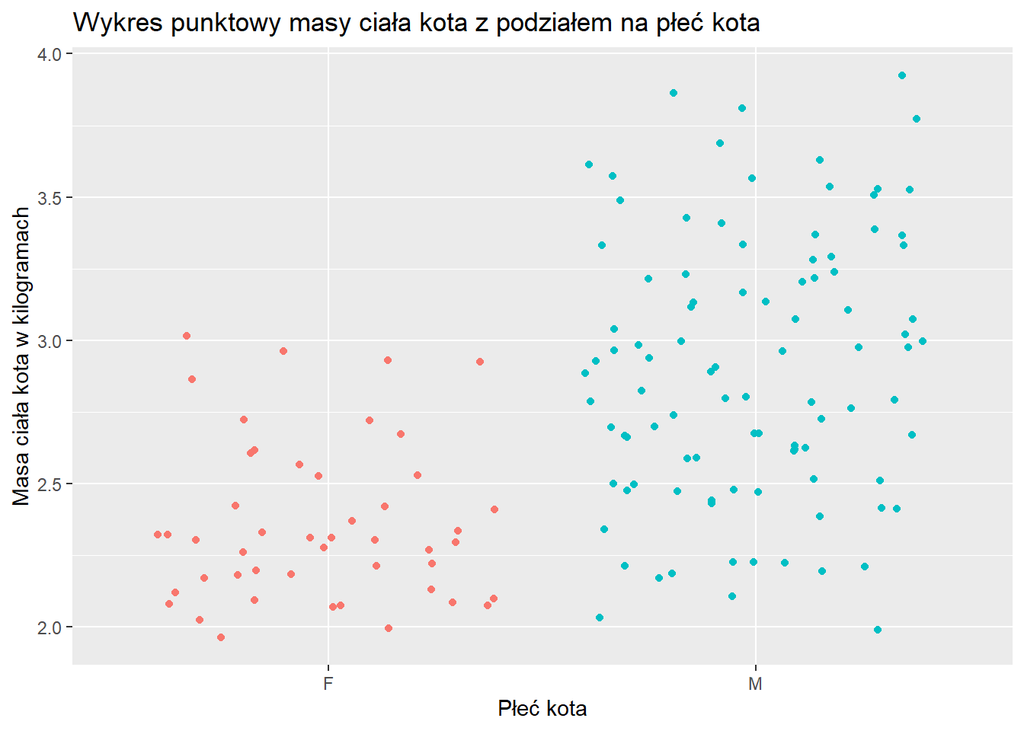

```r
ggplot(cats, aes(x=Sex, y=Bwt)) + geom_point(aes(color=Sex), position='jitter') + labs(title = 'Wykres punktowy masy ciała kota z podziałem na płeć kota', x='Płeć kota', y='Masa ciała kota w kilogramach') + theme(legend.position = 'none')
```

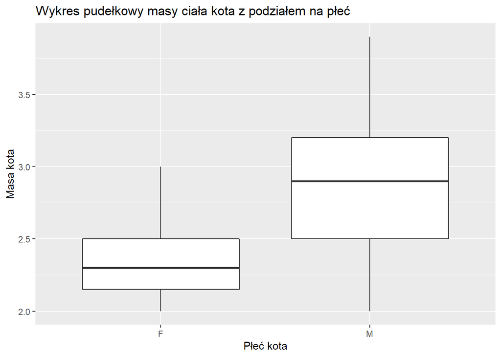

```r
ggplot(cats, aes(x=Sex, y=Bwt)) + geom_boxplot() + labs(title = "Wykres pudełkowy masy ciała kota z podziałem na płeć", x='Płeć kota', y='Masa kota')
```

Ostatnią częścią tej analizy będzie wykonanie testu Welscha w celu potwierdzenia lub zaprzeczenia temu, że średnie w obu grupach są takie same. Na podstawie wykresów można śmiało stwierdzić, że nie są, jednak wykonajmy test. Co prawda test t Welscha wymaga, aby rozkład cechy w obu porównywanych populacjach był normalny, przeprowadzimy go mając świadomość naruszenia tego założenia.

```r
t.test(cats$Hwt[cats$Sex == 'M'] ,cats$Hwt[cats$Sex == 'F'])
```

```
##
##  Welch Two Sample t-test
##
## data:  cats$Hwt[cats$Sex == "M"] and cats$Hwt[cats$Sex == "F"]
## t = 6.5179, df = 140.61, p-value = 1.186e-09
## alternative hypothesis: true difference in means is not equal to 0
## 95 percent confidence interval:
##  1.477352 2.763753
## sample estimates:
## mean of x mean of y
## 11.322680  9.202128
```

Test potwierdza, że średnie masy serca samców i samic kota różnią się. Z otrzymanego przedziału ufności dla różnicy średnich wnioskujemy, że serce samca jest cięższe o około 2 gramy.

Zobaczmy jak sprawy się mają w przypadku masy ciała.

```r
t.test(cats$Bwt[cats$Sex == 'M'] ,cats$Bwt[cats$Sex == 'F'])
```

```
##
##  Welch Two Sample t-test
##
## data:  cats$Bwt[cats$Sex == "M"] and cats$Bwt[cats$Sex == "F"]
## t = 8.7095, df = 136.84, p-value = 8.831e-15
## alternative hypothesis: true difference in means is not equal to 0
## 95 percent confidence interval:
##  0.4177242 0.6631268
## sample estimates:
## mean of x mean of y
##  2.900000  2.359574
```

Tym razem p-wartość jest jeszcze mniejsza, co pozwala nam odrzucić hipotezę zerową mówiącą o równości średnich. Różnica między średnimi masami ciała samic i samców wynosi około pół kilograma.